# CMTH 642 Data Analytics: Advanced Methods

# Assignment 2 (10%)

### DHC 500163559

#### 1. Read the csv file (USDA_Clean.csv) in the folder and assign it to a data frame. (3 points)

```r
dfClean <- read.csv("USDA_Clean.csv")
```

#### 2. Check the datatypes of the attributes. (3 points)

```r
names(dfClean)
```

```
##  [1] "X"            "ID"           "Description"  "Calories"     "Protein"
##  [6] "TotalFat"     "Carbohydrate" "Sodium"       "Cholesterol"  "Sugar"
## [11] "Calcium"      "Iron"         "Potassium"    "VitaminC"     "VitaminE"
## [16] "VitaminD"     "HighSodium"   "HighCals"     "HighSugar"    "HighProtein"
## [21] "HighFat"
```

```r
sapply(dfClean,typeof)
```

```
##            X           ID  Description     Calories      Protein     TotalFat
##    "integer"    "integer"  "character"    "integer"     "double"     "double"
## Carbohydrate       Sodium  Cholesterol        Sugar      Calcium         Iron
##     "double"    "integer"    "integer"     "double"    "integer"     "double"
##    Potassium     VitaminC     VitaminE     VitaminD   HighSodium     HighCals
##    "integer"     "double"     "double"     "double"    "integer"    "integer"
##    HighSugar  HighProtein      HighFat
##    "integer"    "integer"    "integer"
```

#### 3. Visualize the correlation among Calories, Protein, Total Fat, Carbohydrate, Sodium and Cholesterol. (7 points)

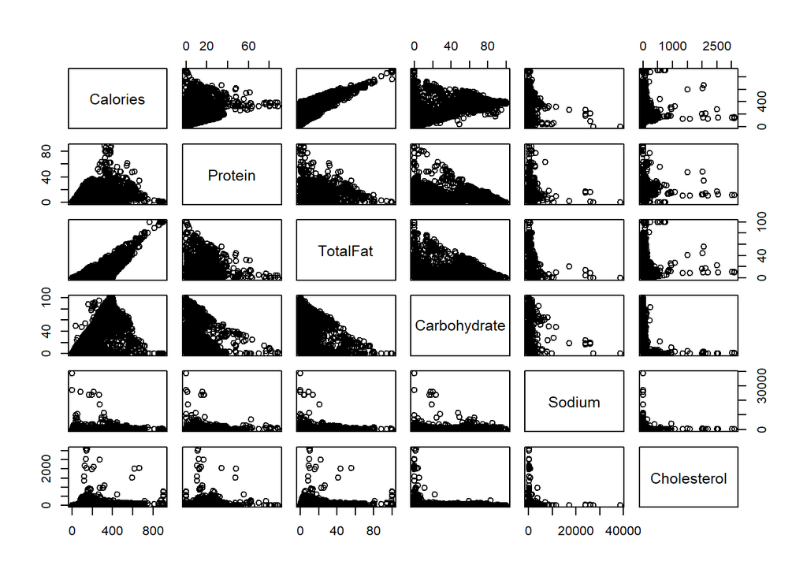

```r
dfClean.isolatedCol <- dfClean[,c("Calories","Protein","TotalFat","Carbohydrate","Sodium","Cholesterol")]
plot(dfClean.isolatedCol)
```

#### 4. Is the correlation between Calories and Total Fat statistically significant? Why? (7 points)

```r
cor(dfClean.isolatedCol)
```

```
##                Calories      Protein     TotalFat Carbohydrate       Sodium
## Calories     1.00000000  0.122122537  0.804495022   0.42460618  0.032321026
## Protein      0.12212254  1.000000000  0.057035611  -0.30471117 -0.003489485
## TotalFat     0.80449502  0.057035611  1.000000000  -0.12434291  0.002916089
## Carbohydrate 0.42460618 -0.304711167 -0.124342914   1.00000000  0.046838692
## Sodium       0.03232103 -0.003489485  0.002916089   0.04683869  1.000000000
## Cholesterol  0.02391933  0.269854840  0.093289601  -0.21937986 -0.017774863
##              Cholesterol
## Calories      0.02391933
## Protein       0.26985484
## TotalFat      0.09328960
## Carbohydrate -0.21937986
## Sodium       -0.01777486
## Cholesterol   1.00000000
```

```r
# Yes. Based on the plots generated in #3, we visually see the plot for Calories and TotalFat resembles a fairly straight line. This hints a correlation between the two. On further inspection using cor(), we can see the correlation between Calories and Total Fat is 0.80. Since it is very close to 1, it confirms our observation that Calories and TotalFat is highly correlated.
```

#### 5. Create a Linear Regression Model, using Calories as the dependent variable Protein, Total Fat, Carbohydrate, Sodium and Cholesterol as the independent variables. (7 points)

```r
# INSERT YOUR CODE HERE.
dfClean.model <- lm(Calories~Protein+TotalFat+Carbohydrate+Sodium+Cholesterol, data=dfClean)
summary(dfClean.model)
```

```
##
## Call:
## lm(formula = Calories ~ Protein + TotalFat + Carbohydrate + Sodium +
##     Cholesterol, data = dfClean)
##
## Residuals:
##      Min       1Q   Median       3Q      Max
## -191.087   -3.832    0.426    5.147  291.011
##
## Coefficients:
##               Estimate Std. Error t value Pr(>|t|)
## (Intercept)  3.9882753  0.4832629   8.253  < 2e-16 ***
## Protein      3.9891994  0.0233550 170.807  < 2e-16 ***
## TotalFat     8.7716980  0.0143291 612.158  < 2e-16 ***
## Carbohydrate 3.7432001  0.0091404 409.522  < 2e-16 ***
## Sodium       0.0003383  0.0002189   1.545    0.122
## Cholesterol  0.0110138  0.0019861   5.545 3.05e-08 ***
## ---
## Signif. codes:  0 '***' 0.001 '**' 0.01 '*' 0.05 '.' 0.1 ' ' 1
##
## Residual standard error: 18.92 on 6304 degrees of freedom
## Multiple R-squared:  0.9877, Adjusted R-squared:  0.9877
## F-statistic: 1.009e+05 on 5 and 6304 DF,  p-value: < 2.2e-16
```

```r
summary(dfClean.model)$coefficient
```

```
##                  Estimate   Std. Error    t value     Pr(>|t|)
## (Intercept)  3.9882752613 0.4832629447   8.252806 1.867166e-16
## Protein      3.9891994394 0.0233549620 170.807361 0.000000e+00
## TotalFat     8.7716980068 0.0143291396 612.158041 0.000000e+00
## Carbohydrate 3.7432000604 0.0091404040 409.522386 0.000000e+00
## Sodium       0.0003383021 0.0002189319   1.545239 1.223386e-01
## Cholesterol  0.0110138110 0.0019860815   5.545498 3.050157e-08
```